# Week-9-Data-Dive-Diagnosing-Regression-Models

Raghuveer Venkatesh

2024-10-29

# Introduction

The goal of this week’s data dive is to deepen our understanding of interpreting and diagnosing regression models, moving beyond basic predictive results to critically evaluating model assumptions and identifying potential issues. We’ll build on the simple linear regression model developed last week, enhancing it by incorporating 1-3 additional variables. Through this exercise, we aim to recognize how adding variables—including interaction and binary terms—impacts model performance, structure, and the relationships between predictors.

Each variable added will be carefully selected, and for each choice, I will discuss the rationale and any potential multi-collinearity concerns. The final model will contain 2-4 terms, optimized for interpret ability and reliability.

Following the model construction, I will evaluate it using the five primary diagnostic plots discussed in class. Each diagnostic plot will be examined for indications of assumption violations, and if issues are identified, I will measure their severity and determine our confidence in the model assumptions.

Finally, for each of the above tasks, I will share insights gained, their significance, and highlight any questions that arise during the analysis, providing a roadmap for further investigation. This structured approach will help ensure a comprehensive understanding of regression model diagnostics and lay a strong foundation for more advanced statistical modeling in the future.

# Identifying Additional Variables

## Overall Rating (overall_rating):

This variable measures the player’s current performance and is expected to be a strong predictor of the market value. Since potential captures future performance while overall rating measure current ability, adding this variable could provide a more balanced view of value influences.

### Building the regression model

```r
# Enhanced regression model with added predictors and interaction term
model2 <- lm(value_euro ~ potential + overall_rating, data = player_data)

# Summarize the enhanced model
model2$r.squared <- summary(model2)$r.squared
model2$adj.r.squared <- summary(model2)$adj.r.squared
```

## Interaction Term (Potential * Age):

Including potential:age accounts for any differing impact of potential based on Age. For example, high potential might matter more for younger players, as they more time to reach their potential whereas for older players, high potential might not boost value much

### Building the regression model

```r
# Enhanced regression model with added predictors and interaction term
model3 <- lm(value_euro ~ potential + overall_rating + age + potential:age, data = player_data)

# Summarize the enhanced model
summary(model3)
```

```
##
## Call:
## lm(formula = value_euro ~ potential + overall_rating + age +
##     potential:age, data = player_data)
##
## Residuals:
##       Min        1Q    Median        3Q       Max
## -15935735  -2107344   -841402   1055079  88290466
##
## Coefficients:
##                  Estimate Std. Error t value Pr(>|t|)
## (Intercept)     4443645.6  1725404.0   2.575     0.01 *
## potential       -440063.1    23694.9 -18.572   <2e-16 ***
## overall_rating   513357.4     9738.0  52.717   <2e-16 ***
## age            -1872065.9    66681.9 -28.075   <2e-16 ***
## potential:age     23779.6      960.3  24.762   <2e-16 ***
## ---
## Signif. codes:  0 '***' 0.001 '**' 0.01 '*' 0.05 '.' 0.1 ' ' 1
##
## Residual standard error: 4288000 on 29124 degrees of freedom
##   (405 observations deleted due to missingness)
## Multiple R-squared:  0.4805, Adjusted R-squared:  0.4804
## F-statistic:  6734 on 4 and 29124 DF,  p-value: < 2.2e-16
```

```r
model3$r.squared <- summary(model3)$r.squared
model3$adj.r.squared <- summary(model3)$adj.r.squared
```

## Wage (wage):

Players earning higher wages are often viewed as more valuable. Including wage might help explain additional variance in value_euro, but it’s worth noting that this variable might be correlated with both potential and overall rating, so checking multi-collinearity will be essential.

# Check for Multicollinearity

```r
library(car)
vif(model3)
```

```
## there are higher-order terms (interactions) in this model
## consider setting type = 'predictor'; see ?vif
```

```
##      potential overall_rating            age  potential:age
##      33.454222       6.814527     145.836248     146.701601
```

# Plotting the change in R-squared value after adding the other two variables

[figure not shown]

```r
df_plot <- data.frame(
  p = c(2, 3, 4),  # Number of predictors in each model
  r_squared = c(model1$r.squared, model2$r.squared, model3$r.squared),
  adj_r_squared = c(model1$adj.r.squared, model2$adj.r.squared, model3$adj.r.squared)
) |>
  mutate(
    r_perc_increase = 100 * round((r_squared - model1$r.squared) / model1$r.squared, 3),
    r_adj_perc_increase = 100 * round((adj_r_squared - model1$adj.r.squared) / model1$adj.r.squared, 3),
    diff = r_perc_increase - r_adj_perc_increase
  )

ggplot(data = df_plot) +
  geom_line(mapping = aes(x = p, y = r_perc_increase, color = 'R Squared Improvement')) +
  geom_line(mapping = aes(x = p, y = r_adj_perc_increase, color = 'Adjusted R Squared Improvement')) +
  geom_text_repel(mapping = aes(x = p, y = r_adj_perc_increase,
                                label = paste("diff =", round(diff, 1))),
                  color = "darkred", nudge_x = 0.3) +
  labs(color = '',
       x = 'Number of Variables (p)',
       y = '% Increase in R-Squared',
       title = "Improving on a Model with 2 Coefficients",
       subtitle = "(Initial Model: R=0.4 and R_adj=0.399)") +
  scale_color_brewer(palette = 'Dark2') +
  theme(legend.position = "bottom")
```

# Diagnostic plots for evaluating the model

- Residuals vs. $\hat{y}$ values
- Residuals vs. $x$ values
- Residual Histogram
- QQ-Plot
- Cook’s D by Observation*

## Residuals vs $\hat{y}$ values

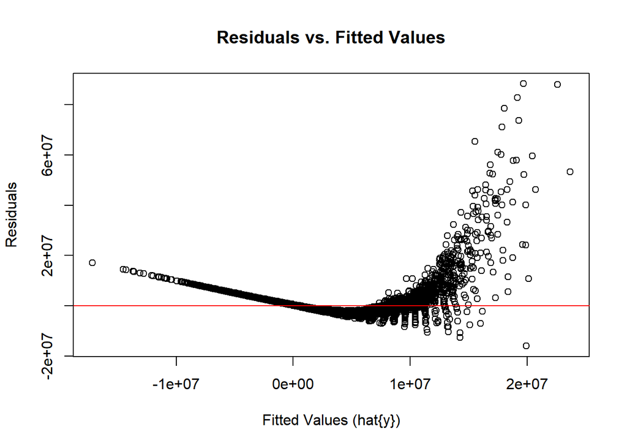

```r
# Fit the model
model3 <- lm(value_euro ~ potential + overall_rating + age + potential:age, data = player_data)

# Calculate fitted values and residuals
fitted_values <- model3$fitted.values
residuals <- model3$residuals

# Plot Residuals vs Fitted Values
plot(fitted_values, residuals,
     xlab = "Fitted Values (hat{y})",
     ylab = "Residuals",
     main = "Residuals vs. Fitted Values")
abline(h = 0, col = "red")  # Horizontal line at 0
```

### Interpretation

The curved pattern in residuals suggests the model doesn’t fully capture the relationship, indicating possible non-linearity. Additionally, the increasing spread of residuals shows heteroscedasticity, meaning the model’s errors vary with fitted values.

## Residuals vs X-values

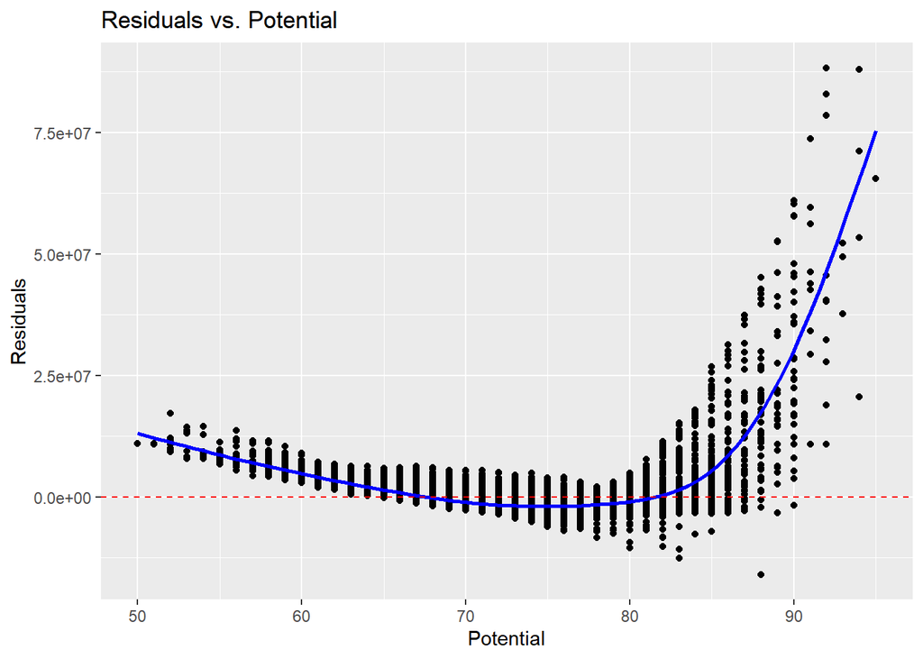

```r
# Extract the data used in the model
model_data <- model.frame(model3)

# Extract residuals and add them to model_data
plot_data <- data.frame(
  potential = model_data$potential,
  overall_rating = model_data$overall_rating,
  age = model_data$age,
  residuals = residuals(model3)
)

# Residuals vs. Potential
ggplot(plot_data, aes(x = potential, y = residuals)) +
  geom_point() +
  geom_smooth(se = FALSE, color = "blue") +
  geom_hline(yintercept = 0, linetype = "dashed", color = "red") +
  labs(title = "Residuals vs. Potential", x = "Potential", y = "Residuals")
```

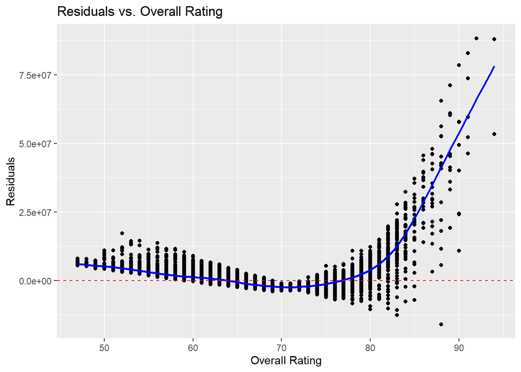

```r
# Residuals vs. Overall Rating
ggplot(plot_data, aes(x = overall_rating, y = residuals)) +
  geom_point() +
  geom_smooth(se = FALSE, color = "blue") +
  geom_hline(yintercept = 0, linetype = "dashed", color = "red") +
  labs(title = "Residuals vs. Overall Rating", x = "Overall Rating", y = "Residuals")
```

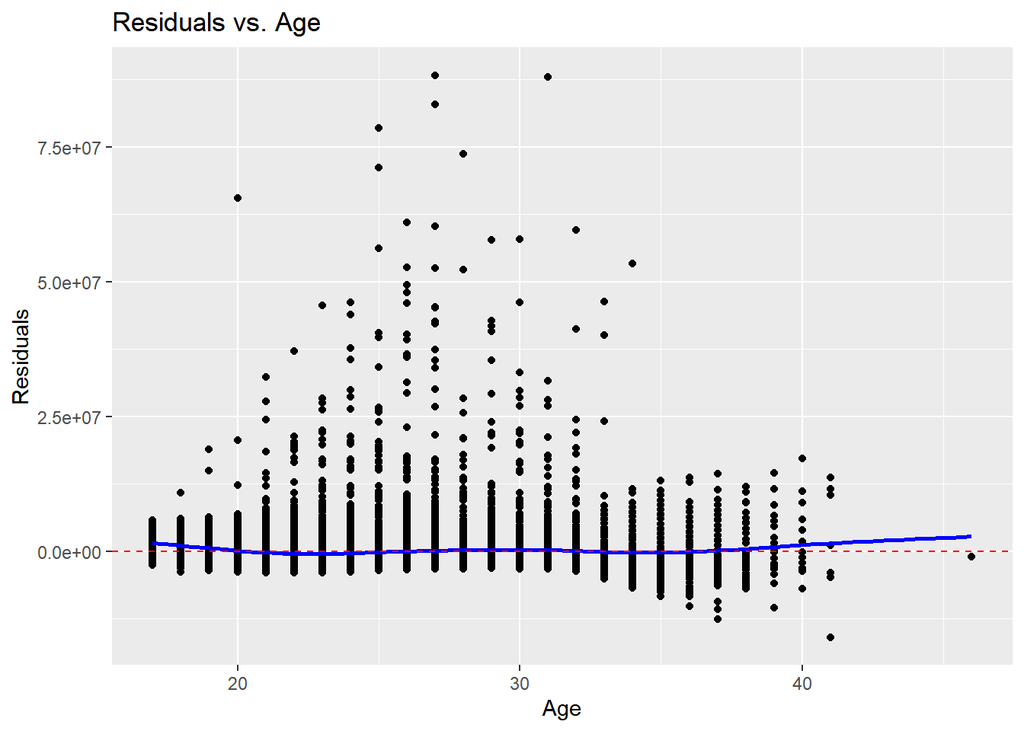

```r
# Residuals vs. Age
ggplot(plot_data, aes(x = age, y = residuals)) +
  geom_point() +
  geom_smooth(se = FALSE, color = "blue") +
  geom_hline(yintercept = 0, linetype = "dashed", color = "red") +
  labs(title = "Residuals vs. Age", x = "Age", y = "Residuals")
```

### Interpretation

Only Age exhibits linearity with the residuals, the other variables like overall rating and potential don’t exhibit this especially at higher values. So we would have to investigate the higher data points like Potential > 80 and Overall rating > 80 to check if there are any other factors influencing the same.

## Residual Histogram

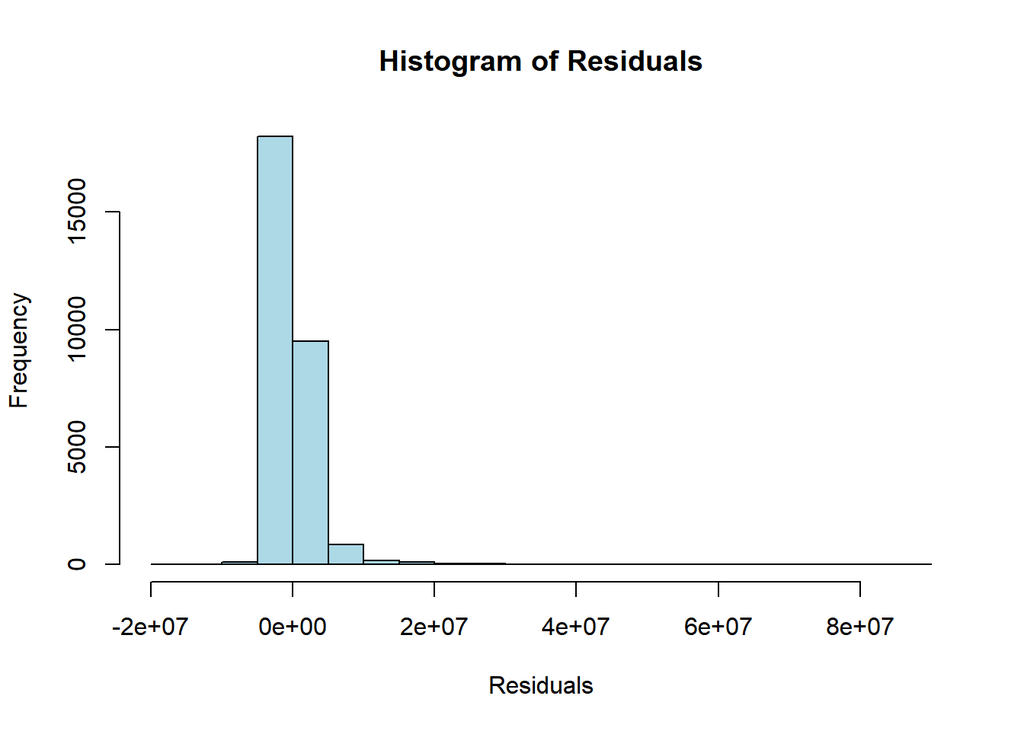

```r
# Histogram of Residuals
hist(residuals, breaks = 30,
     main = "Histogram of Residuals",
     xlab = "Residuals",
     col = "lightblue")
```

### Interpretation

There is a shorter tail on the left compared to the right where we want to see a normal distribution which indicates that we may need different variables and we are missing some phenomenon which is causing this skew.

## QQ-Plot

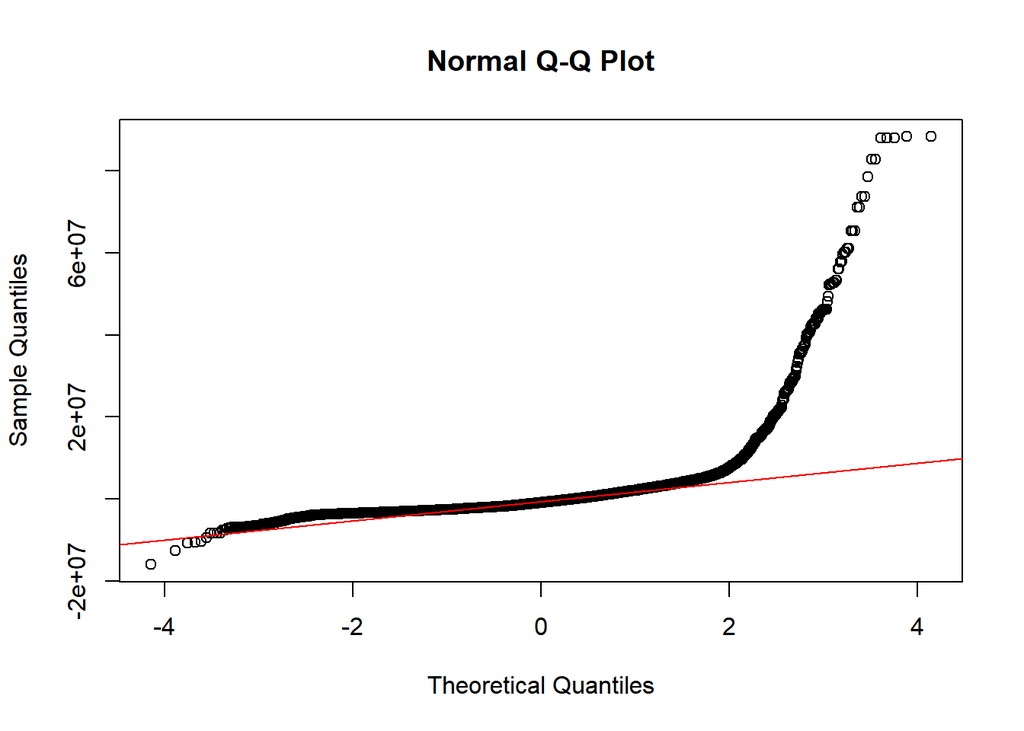

```r
# QQ-Plot
qqnorm(residuals)
qqline(residuals, col = "red")
```